# Zantiks manipulation scripts

```r
library(tidyverse)
library(lme4)
library(MCMCglmm)
```

# Locomotion

## Data parsing

First let’s test-load one data file to see how to trim it into relevant bits. Definition in this files is so that first 4 rows and firts 6 columns are redundant.

The first portion loads and parses the raw datafile lines.

```r
data_path = './data/locomotion/'
data_files = list.files('./data/locomotion/', recursive = T)
head(data_files)
```

```
## [1] "210422/E_locomotion_traking-20000228T224844.csv"
## [2] "210422/E_locomotion_traking-20000229T005421.csv"
## [3] "210422/E_locomotion_traking-20000229T031017.csv"
## [4] "210422/E_locomotion_traking-20000229T043418.csv"
## [5] "210423/E_locomotion_traking-20000229T224459.csv"
## [6] "210423/E_locomotion_traking-20000301T001741.csv"
```

```r
dat_temp = readLines(paste(data_path, data_files[2], sep = ''))

dat_temp_df = read.csv(text = dat_temp, header = T, sep = ',',
                        quote = '\"', dec = '.', skip = 4, nrows = length(dat_temp) - 4 - 2,
                        stringsAsFactors = F)

dat_temp_df = dat_temp_df[, -(2:6)]
dat_temp_df = dat_temp_df %>% select(!(F6:F8))
dat_temp_df
```

```
##       TIME TEMPERATURE ROUND         VARIABLE   A1    A2    A3  A4  A5 A6   A7
## 1  964.295       24.60     1 BINARENADISTANCE  1.6  30.4  14.2 1.4 3.0  0 11.8
## 2 1324.299       25.04     2 BINARENADISTANCE  3.2 204.5  10.4 0.0 3.0  0 12.3
## 3 1684.303       24.96     3 BINARENADISTANCE  8.8  16.5  76.8 3.0 6.3  0 16.5
## 4 2044.314       24.96     4 BINARENADISTANCE  1.6  23.0 140.4 4.4 2.8  0 32.7
## 5 2404.317       24.78     5 BINARENADISTANCE 59.2  57.8  93.5 0.0 6.0  0 28.5
##     A8    B1   B2 B3  B4     B5    B6    B7   B8   C1 C2  C3  C4   C5    C6
## 1  0.0   1.4  5.8  0 4.4    8.8   7.2   0.0  4.4  5.8  0 1.4 3.0  1.4   1.6
## 2  0.0  20.9  8.8  0 4.4   40.8   8.8   3.2 15.8 10.2  0 0.0 3.0  7.9   9.1
## 3  4.4  17.4 13.7  0 3.0  448.4  23.2  19.7  6.0 10.7  0 0.0 1.4 21.4 209.6
## 4  8.1   3.0  0.0  0 8.8  861.1  68.5  18.1 10.2 10.7  0 1.6 4.2 15.3  85.4
## 5 14.4 296.9 27.4  0 8.8 1415.4 101.7 148.8 16.7 64.5  0 0.0 0.0 11.8 246.3
##     C7   C8   D1   D2  D3  D4   D5 D6   D7   D8   E1  E2  E3   E4  E5   E6   E7
## 1  1.4  0.0  0.0  8.8 0.0 1.4  1.4  0  4.4  9.1  7.7 4.4 0.0  0.0 1.4  2.8  1.6
## 2  2.8  3.2  3.0  8.8 0.0 0.0  4.4  0 10.4 11.6  6.0 0.0 1.4  3.0 1.4 11.8  1.4
## 3 20.0  1.6 15.6 11.6 4.4 3.0  6.0  0 11.6 12.1  3.2 5.8 0.0  1.4 4.4 14.9  3.0
## 4  8.1 31.8 13.5 24.1 1.4 4.4  4.4  0 15.6 10.7 21.1 9.1 1.4  1.4 1.4 23.2  4.6
## 5  6.0 32.5 61.5  9.3 7.2 3.2 41.3  0 37.8  6.0 32.0 3.0 0.0 10.7 7.2 20.7 12.1
##     E8   F1    F2   F3  F4  F5
## 1  7.4 10.4   1.4  3.0 1.4 1.4
## 2  7.2  5.8   4.4 10.2 3.0 1.4
## 3 10.2  4.9   8.8  9.1 0.0 4.4
## 4  7.4 95.4 157.1 10.4 5.8 3.0
## 5  0.0 32.7 152.7  9.1 1.4 4.9
```

Here we extract and append the run (subject) ID.

```r
head_temp = readLines(paste(data_path, data_files[1], sep = ''), n = 4)
id_index = grep('.*Subject Identification\\",\\"([A-Z0-9]{7}_[A-B0-9_]*)\\"', head_temp)
run_id = gsub('.*Subject Identification\\",\\"([A-Z0-9]{7}_[A-B0-9_]*)\\"', '\\1', head_temp[id_index])
dat_temp_df$run_id = run_id

assay_date = gsub('([0-9]{6})/E_[A-Za-z_]+-[0-9A-Z]+.csv', '\\1', data_files[1])
dat_temp_df$date = assay_date
dat_temp_df
```

```
##       TIME TEMPERATURE ROUND         VARIABLE   A1    A2    A3  A4  A5 A6   A7
## 1  964.295       24.60     1 BINARENADISTANCE  1.6  30.4  14.2 1.4 3.0  0 11.8
## 2 1324.299       25.04     2 BINARENADISTANCE  3.2 204.5  10.4 0.0 3.0  0 12.3
## 3 1684.303       24.96     3 BINARENADISTANCE  8.8  16.5  76.8 3.0 6.3  0 16.5
## 4 2044.314       24.96     4 BINARENADISTANCE  1.6  23.0 140.4 4.4 2.8  0 32.7
## 5 2404.317       24.78     5 BINARENADISTANCE 59.2  57.8  93.5 0.0 6.0  0 28.5
##     A8    B1   B2 B3  B4     B5    B6    B7   B8   C1 C2  C3  C4   C5    C6
## 1  0.0   1.4  5.8  0 4.4    8.8   7.2   0.0  4.4  5.8  0 1.4 3.0  1.4   1.6
## 2  0.0  20.9  8.8  0 4.4   40.8   8.8   3.2 15.8 10.2  0 0.0 3.0  7.9   9.1
## 3  4.4  17.4 13.7  0 3.0  448.4  23.2  19.7  6.0 10.7  0 0.0 1.4 21.4 209.6
## 4  8.1   3.0  0.0  0 8.8  861.1  68.5  18.1 10.2 10.7  0 1.6 4.2 15.3  85.4
## 5 14.4 296.9 27.4  0 8.8 1415.4 101.7 148.8 16.7 64.5  0 0.0 0.0 11.8 246.3
##     C7   C8   D1   D2  D3  D4   D5 D6   D7   D8   E1  E2  E3   E4  E5   E6   E7
## 1  1.4  0.0  0.0  8.8 0.0 1.4  1.4  0  4.4  9.1  7.7 4.4 0.0  0.0 1.4  2.8  1.6
## 2  2.8  3.2  3.0  8.8 0.0 0.0  4.4  0 10.4 11.6  6.0 0.0 1.4  3.0 1.4 11.8  1.4
## 3 20.0  1.6 15.6 11.6 4.4 3.0  6.0  0 11.6 12.1  3.2 5.8 0.0  1.4 4.4 14.9  3.0
## 4  8.1 31.8 13.5 24.1 1.4 4.4  4.4  0 15.6 10.7 21.1 9.1 1.4  1.4 1.4 23.2  4.6
## 5  6.0 32.5 61.5  9.3 7.2 3.2 41.3  0 37.8  6.0 32.0 3.0 0.0 10.7 7.2 20.7 12.1
##     E8   F1    F2   F3  F4  F5             run_id   date
## 1  7.4 10.4   1.4  3.0 1.4 1.4 Z0107D3_B_210421_1 210422
## 2  7.2  5.8   4.4 10.2 3.0 1.4 Z0107D3_B_210421_1 210422
## 3 10.2  4.9   8.8  9.1 0.0 4.4 Z0107D3_B_210421_1 210422
## 4  7.4 95.4 157.1 10.4 5.8 3.0 Z0107D3_B_210421_1 210422
## 5  0.0 32.7 152.7  9.1 1.4 4.9 Z0107D3_B_210421_1 210422
```

Change to long format with individual IDs formed by merging plate ID and run ID.

```r
dat_temp_df =
  dat_temp_df %>%
  pivot_longer(names_to = 'well_id', values_to = 'arena_distance', cols = matches('[A-H][1-9]')) %>%
  unite(col = 'indiv_id', c(run_id, well_id), sep = '_', remove = F)

dat_temp_df
```

```
## # A tibble: 225 x 9
##     TIME TEMPERATURE ROUND VARIABLE indiv_id run_id date  well_id arena_distance
##    <dbl>       <dbl> <int> <chr>    <chr>    <chr>  <chr> <chr>            <dbl>
##  1  964.        24.6     1 BINAREN… Z0107D3… Z0107… 2104… A1                 1.6
##  2  964.        24.6     1 BINAREN… Z0107D3… Z0107… 2104… A2                30.4
##  3  964.        24.6     1 BINAREN… Z0107D3… Z0107… 2104… A3                14.2
##  4  964.        24.6     1 BINAREN… Z0107D3… Z0107… 2104… A4                 1.4
##  5  964.        24.6     1 BINAREN… Z0107D3… Z0107… 2104… A5                 3
##  6  964.        24.6     1 BINAREN… Z0107D3… Z0107… 2104… A6                 0
##  7  964.        24.6     1 BINAREN… Z0107D3… Z0107… 2104… A7                11.8
##  8  964.        24.6     1 BINAREN… Z0107D3… Z0107… 2104… A8                 0
##  9  964.        24.6     1 BINAREN… Z0107D3… Z0107… 2104… B1                 1.4
## 10  964.        24.6     1 BINAREN… Z0107D3… Z0107… 2104… B2                 5.8
## # … with 215 more rows
```

Now - let’s apply this in a loop to all available files.

```r
dat_df <- NULL
for (file_i in data_files) {

  # file parsing
  dat_temp = readLines(paste(data_path, file_i, sep = ''))
  dat_temp_df = read.csv(text = dat_temp, header = T, sep = ',',
                         quote = '\"', dec = '.', skip = 4, nrows = length(dat_temp) - 4 - 2,
                         stringsAsFactors = F)
  dat_temp_df = dat_temp_df[, -(2:6)]
  dat_temp_df = dat_temp_df %>% select(!(F6:F8))

  # extract headers
  head_temp = readLines(paste(data_path, file_i, sep = ''), n = 4)
  id_index = grep('.*Subject Identification\\",\\"([A-Z0-9]{7}_[A-B0-9_]*)\\"', head_temp)
  run_id = gsub('.*Subject Identification\\",\\"([A-Z0-9]{7}_[A-B0-9_]*)\\"', '\\1', head_temp[id_index])
  cat(run_id); cat('\n')
  dat_temp_df$run_id = run_id
  assay_date = gsub('([0-9]{6})/E_[A-Za-z_]+-[0-9A-Z]+.csv', '\\1', file_i)
  dat_temp_df$date = assay_date

  # tidy
  dat_temp_df =
  dat_temp_df %>%
  pivot_longer(names_to = "well_id", values_to = "arena_distance", cols = matches('[A-H][1-9]')) %>%
  unite(col = 'indiv_id', c(run_id, well_id), sep = '_', remove = F)


  # merge into larger file
  if(is.null(dat_df)) dat_df = dat_temp_df else dat_df = rbind(dat_df, dat_temp_df)
}
```

```
## Z0107D3_B_210421_1
## Z0107D3_B_210421_3
## Z0107D3_B_220421_9
## Z0107D3_B_220421_11
## Z0107D3_B_220421_9
## Z0107D3_B_220421_11
## Z0107D3_B_220421_13
## Z0107D3_B_220421_15
```

```r
dat_df
```

```
## # A tibble: 1,800 x 9
##     TIME TEMPERATURE ROUND VARIABLE indiv_id run_id date  well_id arena_distance
##    <dbl>       <dbl> <int> <chr>    <chr>    <chr>  <chr> <chr>            <dbl>
##  1  964.        24.8     1 BINAREN… Z0107D3… Z0107… 2104… A1                 0
##  2  964.        24.8     1 BINAREN… Z0107D3… Z0107… 2104… A2                12.5
##  3  964.        24.8     1 BINAREN… Z0107D3… Z0107… 2104… A3                 2.8
##  4  964.        24.8     1 BINAREN… Z0107D3… Z0107… 2104… A4                 1.4
##  5  964.        24.8     1 BINAREN… Z0107D3… Z0107… 2104… A5                 3.2
##  6  964.        24.8     1 BINAREN… Z0107D3… Z0107… 2104… A6                 8.6
##  7  964.        24.8     1 BINAREN… Z0107D3… Z0107… 2104… A7                 4.6
##  8  964.        24.8     1 BINAREN… Z0107D3… Z0107… 2104… A8                 1.4
##  9  964.        24.8     1 BINAREN… Z0107D3… Z0107… 2104… B1                 3
## 10  964.        24.8     1 BINAREN… Z0107D3… Z0107… 2104… B2                 6
## # … with 1,790 more rows
```

## Simple viz

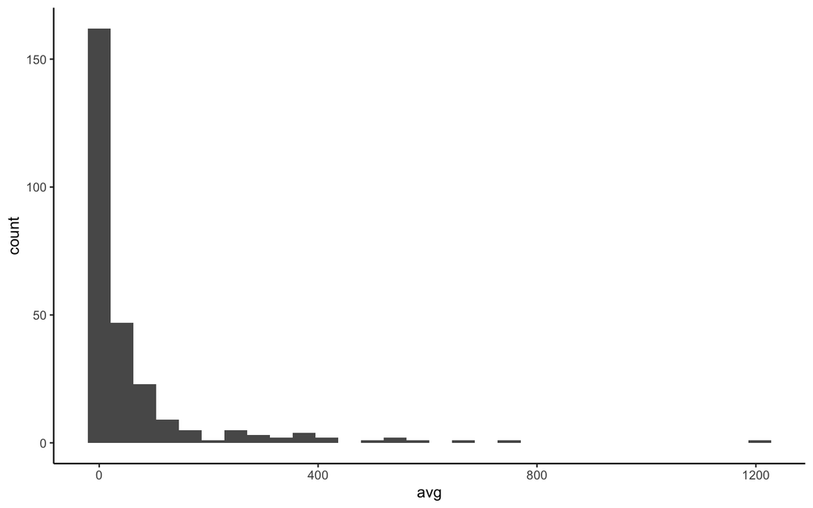

```r
dat_df_avg = dat_df %>%
  group_by(indiv_id) %>%
  summarise(avg = mean(arena_distance))

# raw data variation
dat_df_avg %>%
  ggplot(aes(x = avg)) +
  geom_histogram() +
  theme_classic()
```

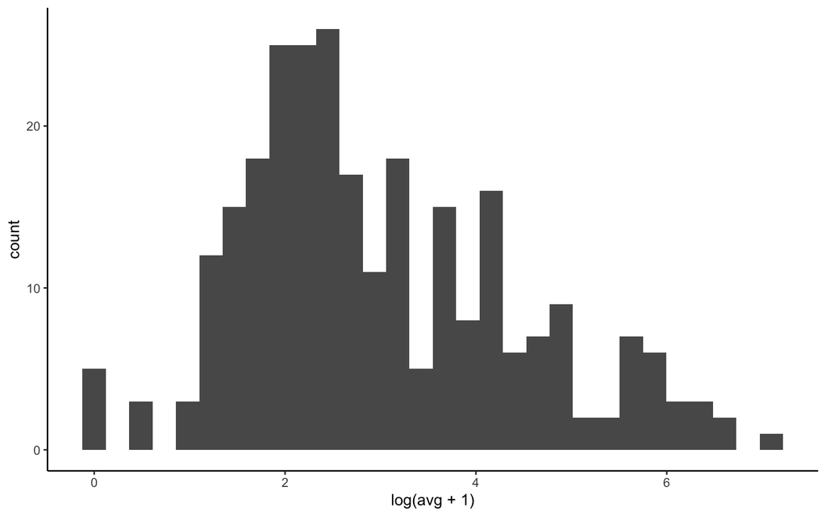

```r
# log scale
dat_df_avg %>%
  ggplot(aes(x = log(avg+1))) +
  geom_histogram() +
  theme_classic()
```

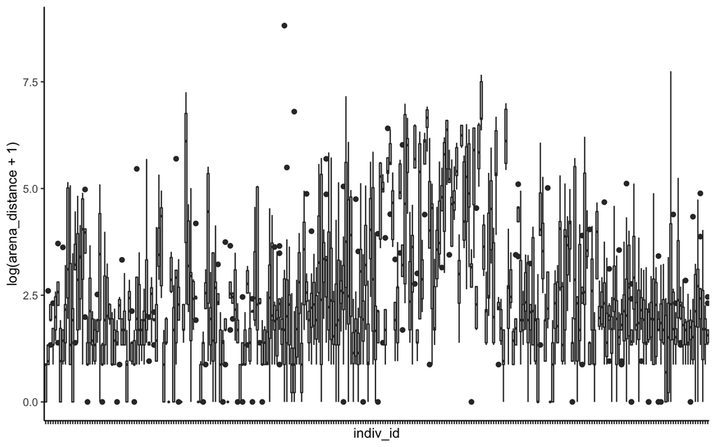

```r
dat_df %>%
  ggplot(aes(x = indiv_id, y = log(arena_distance+1))) +
  geom_boxplot() + theme_classic() + theme(axis.text.x = element_blank())
```

## Mixed-model with between-individual variation

```r
model1 = lmer(log(arena_distance+1) ~ ROUND + date + (1|indiv_id) + (1|run_id),
              data = dat_df)
summary(model1)
```

```
## Linear mixed model fit by REML ['lmerMod']
## Formula: log(arena_distance + 1) ~ ROUND + date + (1 | indiv_id) + (1 |
##     run_id)
##    Data: dat_df
##
## REML criterion at convergence: 5787.2
##
## Scaled residuals:
##     Min      1Q  Median      3Q     Max
## -2.9811 -0.6032 -0.0163  0.5312  6.5245
##
## Random effects:
##  Groups   Name        Variance Std.Dev.
##  indiv_id (Intercept) 0.8136   0.9020
##  run_id   (Intercept) 0.9118   0.9549
##  Residual             1.1057   1.0515
## Number of obs: 1800, groups:  indiv_id, 270; run_id, 6
##
## Fixed effects:
##             Estimate Std. Error t value
## (Intercept)  1.95274    0.39955   4.887
## ROUND        0.22394    0.01753  12.778
## date210423  -0.25358    0.06992  -3.627
##
## Correlation of Fixed Effects:
##            (Intr) ROUND
## ROUND      -0.132
## date210423 -0.087  0.000
```

```r
model1mc <- MCMCglmm(log(arena_distance+1) ~ ROUND + date,
                     random = ~ indiv_id + run_id,
                     data = as.data.frame(dat_df), verbose = F,
                     prior = list(R = list(V = 1, nu = 0.002),
                                  G = list(G1 = list(V = 1, nu = 0.002),
                                           G2 = list(V = 1, nu = 0.002))),
                     nitt = 5e4, burnin = 1e4, thin = 40)
# plot(model1mc)
mean(model1mc$VCV[,"indiv_id"]/rowSums(model1mc$VCV))
```

```
## [1] 0.2615006
```

```r
HPDinterval(model1mc$VCV[,"indiv_id"]/rowSums(model1mc$VCV))
```

```
##          lower     upper
## var1 0.1023894 0.3838901
## attr(,"Probability")
## [1] 0.95
```

# Y-maze

## Data loading

First we load the y-maze data and tidy it up to separate summary data from zone changes data.

```r
# parse datafiles into a nested tibble
data_path = './data/ymaze/'
data_files = list.files('./data/ymaze/', recursive = T)
head(data_files)
```

```
## [1] "210422/E_ymaze_droso-20210422T231729.csv"
## [2] "210422/E_ymaze_droso-20210423T005010.csv"
## [3] "210422/E_ymaze_droso-20210423T033805.csv"
## [4] "210422/E_ymaze_droso-20210423T050533.csv"
## [5] "210423/E_ymaze_droso-20210421T232255.csv"
## [6] "210423/E_ymaze_droso-20210422T005300.csv"
```

```r
# helper functions extracting the data rows and the header rows
data_parser = function(pattern, path, filename, summary = F) {
  dat_temp = readLines(paste(path, filename, sep = ''))
  zone_change_index = grep(pattern, dat_temp)

  if(!summary) {
    return(read_delim(file = dat_temp[zone_change_index], col_names = F, delim = ',',
                      quote = '\"' # skip = 4, nrows = length(dat_temp) - 4 - 1)
    ))
  } else {
    return(read_delim(file = dat_temp[-zone_change_index], col_names = T, delim = ',',
                      quote = '\"', skip = 6, n_max = 3))
  }
}

head_parser = function(path, filename) {
  dat_temp = readLines(paste(path, filename, sep = ''), n = 4)
  return(read_delim(file = dat_temp,
                    delim = ',',
                    col_names = F))
}

# create tibble with raw data (nested: data nad header nested under file names)
dat_raw = tibble(data_files = data_files) %>%
  mutate(data = map(data_files,
                    ~ data_parser('[0-9]{3,4}.[0-9]{3},\\"Info\\",\\"Arena\\",[0-9]{1,2},\\"(?:Enter|Exit)_Zone\\",[0-9]',
                                data_path,
                                .x))) %>%
  mutate(head = map(data_files, ~ head_parser(data_path, .x)))
dat_raw[[2]] = dat_raw[[2]] %>%
  map(~ select(.x, !c(X3)))

# rename variables in sub-tibble
dat_raw[[2]] = dat_raw[[2]] %>%
  map(~ rename(.x, time = X1, info = X2, arena = X4, action = X5, zone_no = X6))

# reformat the head sub-tibble
dat_raw[[3]] = dat_raw[[3]] %>%
  map(~ pivot_wider(.x, names_from = X3, values_from = X4)) %>%
  map(~ select(.x, 'X1', 'X2', 'Apparatus', 'Subject Identification'))

dat_raw[[2]][[1]]
```

```
## # A tibble: 5,555 x 5
##     time info  arena action     zone_no
##    <dbl> <chr> <dbl> <chr>        <dbl>
##  1  601. Info      1 Enter_Zone       4
##  2  601. Info      3 Enter_Zone       4
##  3  601. Info      4 Enter_Zone       4
##  4  601. Info      5 Enter_Zone       1
##  5  601. Info      7 Enter_Zone       3
##  6  601. Info      9 Enter_Zone       4
##  7  601. Info     10 Enter_Zone       3
##  8  601. Info     11 Enter_Zone       4
##  9  601. Info     12 Enter_Zone       4
## 10  601. Info     13 Enter_Zone       2
## # … with 5,545 more rows
```

```r
dat_raw[[3]][[1]]
```

```
## # A tibble: 1 x 4
##      X1 X2    Apparatus        `Subject Identification`
##   <dbl> <chr> <chr>            <chr>
## 1     0 Info  Zantiks MWP Unit Z5B0E17_B_220421_9
```

```r
# parse summary data from a file into a separate tibble
dat_raw_summ = tibble(data_files = data_files) %>%
  mutate(data = map(data_files,
                    ~ data_parser('[0-9]{3,4}.[0-9]{3},\\"Info\\",\\"Arena\\",[0-9]{1,2},\\"(?:Enter|Exit)_Zone\\",[0-9]',
                                data_path,
                                .x,
                                summary = T)))
dat_raw_summ[[2]] = dat_raw_summ[[2]] %>%
  map(~ select(.x, !c(X2, X3)))
dat_raw_summ[[2]][[1]]
```

```
## # A tibble: 3 x 47
##      X1 X4        A1_ZONE1 A1_ZONE2 A1_ZONE3 A2_ZONE1 A2_ZONE2 A2_ZONE3 A3_ZONE1
##   <dbl> <chr>        <dbl>    <dbl>    <dbl>    <dbl>    <dbl>    <dbl>    <dbl>
## 1 2402. TOTAL_ZO…     24.2      3.4     22.5       0        8         0      2.9
## 2 2402. TOTAL_ZO…      3        1        8       298       59         0     60
## 3 2402. TOTAL_ZO…    944.      81.4    199.      305.     646.        0    176.
## # … with 38 more variables: A3_ZONE2 <dbl>, A3_ZONE3 <dbl>, A4_ZONE1 <dbl>,
## #   A4_ZONE2 <dbl>, A4_ZONE3 <dbl>, A5_ZONE1 <dbl>, A5_ZONE2 <dbl>,
## #   A5_ZONE3 <dbl>, A6_ZONE1 <dbl>, A6_ZONE2 <dbl>, A6_ZONE3 <dbl>,
## #   A7_ZONE1 <dbl>, A7_ZONE2 <dbl>, A7_ZONE3 <dbl>, A8_ZONE1 <dbl>,
## #   A8_ZONE2 <dbl>, A8_ZONE3 <dbl>, A9_ZONE1 <dbl>, A9_ZONE2 <dbl>,
## #   A9_ZONE3 <dbl>, A10_ZONE1 <dbl>, A10_ZONE2 <dbl>, A10_ZONE3 <dbl>,
## #   A11_ZONE1 <dbl>, A11_ZONE2 <dbl>, A11_ZONE3 <dbl>, A12_ZONE1 <dbl>,
## #   A12_ZONE2 <dbl>, A12_ZONE3 <dbl>, A13_ZONE1 <dbl>, A13_ZONE2 <dbl>,
## #   A13_ZONE3 <dbl>, A14_ZONE1 <dbl>, A14_ZONE2 <dbl>, A14_ZONE3 <dbl>,
## #   A15_ZONE1 <dbl>, A15_ZONE2 <dbl>, A15_ZONE3 <dbl>
```

Unnest the tibble and select relevant variables.

```r
dat_un <- dat_raw
dat_un = dat_raw %>%
  unnest(head) %>%
  unnest(data)

dat_un = dat_un %>%
  select(data_files, `Subject Identification`, time, arena, action, zone_no) %>%
  rename(run_id = `Subject Identification`)

dat_un = na.omit(dat_un)
dat_un
```

```
## # A tibble: 30,679 x 6
##    data_files                       run_id           time arena action   zone_no
##    <chr>                            <chr>           <dbl> <dbl> <chr>      <dbl>
##  1 210422/E_ymaze_droso-20210422T2… Z5B0E17_B_2204…  601.     1 Enter_Z…       4
##  2 210422/E_ymaze_droso-20210422T2… Z5B0E17_B_2204…  601.     3 Enter_Z…       4
##  3 210422/E_ymaze_droso-20210422T2… Z5B0E17_B_2204…  601.     4 Enter_Z…       4
##  4 210422/E_ymaze_droso-20210422T2… Z5B0E17_B_2204…  601.     5 Enter_Z…       1
##  5 210422/E_ymaze_droso-20210422T2… Z5B0E17_B_2204…  601.     7 Enter_Z…       3
##  6 210422/E_ymaze_droso-20210422T2… Z5B0E17_B_2204…  601.     9 Enter_Z…       4
##  7 210422/E_ymaze_droso-20210422T2… Z5B0E17_B_2204…  601.    10 Enter_Z…       3
##  8 210422/E_ymaze_droso-20210422T2… Z5B0E17_B_2204…  601.    11 Enter_Z…       4
##  9 210422/E_ymaze_droso-20210422T2… Z5B0E17_B_2204…  601.    12 Enter_Z…       4
## 10 210422/E_ymaze_droso-20210422T2… Z5B0E17_B_2204…  601.    13 Enter_Z…       2
## # … with 30,669 more rows
```

TUrn into wider format with enter/exit columns, add row ID to maintain order if needed.

```r
dat_un = dat_un %>%
  mutate(row_id = row_number()) %>%
  pivot_wider(names_from = action, values_from = zone_no) %>%
  rename(enter_zone = Enter_Zone, exit_zone = Exit_Zone)
```

Bin into 10-min intervals (if binning would be needed or only first 10 mins of exploration used). Then sort the dataset into individual arenas and chronologically within arenas, and then in enter-exit order at the lowest level.

```r
dat_an = dat_un

dat_an = dat_an %>%
  mutate(bin = ifelse(time > 600 & time < 1200, 1,
                      ifelse(time > 1200 & time < 1800, 2,
                             ifelse(time > 1800 & time < 2500, 3, NA))))

dat_an = dat_an %>%
  arrange(data_files, run_id, arena, time, exit_zone)
dat_an
```

```
## # A tibble: 30,679 x 8
##    data_files           run_id      time arena row_id enter_zone exit_zone   bin
##    <chr>                <chr>      <dbl> <dbl>  <int>      <dbl>     <dbl> <dbl>
##  1 210422/E_ymaze_dros… Z5B0E17_B…  601.     1      1          4        NA     1
##  2 210422/E_ymaze_dros… Z5B0E17_B…  826.     1   2288         NA         4     1
##  3 210422/E_ymaze_dros… Z5B0E17_B…  826.     1   2289          2        NA     1
##  4 210422/E_ymaze_dros… Z5B0E17_B…  908.     1   3102         NA         2     1
##  5 210422/E_ymaze_dros… Z5B0E17_B…  908.     1   3103          4        NA     1
##  6 210422/E_ymaze_dros… Z5B0E17_B…  997.     1   3844         NA         4     1
##  7 210422/E_ymaze_dros… Z5B0E17_B…  997.     1   3845          3        NA     1
##  8 210422/E_ymaze_dros… Z5B0E17_B… 1147.     1   3880         NA         3     1
##  9 210422/E_ymaze_dros… Z5B0E17_B… 1147.     1   3881          4        NA     1
## 10 210422/E_ymaze_dros… Z5B0E17_B… 1147.     1   3882         NA         4     1
## # … with 30,669 more rows
```

Error checking - do all enter zones have a matching exit zone (if enter and exit exist)?

```r
dat_an = dat_an %>%
  mutate(zone = ifelse(enter_zone == lead(exit_zone), enter_zone, 666)) %>%
  mutate(t_enter = ifelse(enter_zone >= 1, time, 666)) %>%
  mutate(t_exit = ifelse(exit_zone >= 1, time, 666))

dat_an %>% filter(zone == 666)
```

```
## # A tibble: 0 x 11
## # … with 11 variables: data_files <chr>, run_id <chr>, time <dbl>, arena <dbl>,
## #   row_id <int>, enter_zone <dbl>, exit_zone <dbl>, bin <dbl>, zone <dbl>,
## #   t_enter <dbl>, t_exit <dbl>
```

```r
dat_an %>% filter(t_enter == 666)
```

```
## # A tibble: 0 x 11
## # … with 11 variables: data_files <chr>, run_id <chr>, time <dbl>, arena <dbl>,
## #   row_id <int>, enter_zone <dbl>, exit_zone <dbl>, bin <dbl>, zone <dbl>,
## #   t_enter <dbl>, t_exit <dbl>
```

```r
dat_an %>% filter(t_exit == 666)
```

```
## # A tibble: 0 x 11
## # … with 11 variables: data_files <chr>, run_id <chr>, time <dbl>, arena <dbl>,
## #   row_id <int>, enter_zone <dbl>, exit_zone <dbl>, bin <dbl>, zone <dbl>,
## #   t_enter <dbl>, t_exit <dbl>
```

```r
# ALL GOOD! Note - this step is v. important and serves to test
# if datapoints were sorted correctly
```

Simplify data by putting enter and exit data in one row:

```r
dat_an = dat_an %>%
  select(data_files, run_id, time, arena, row_id, bin, zone, t_enter, t_exit)
dat_an = dat_an %>%
  mutate(t_exit = lead(t_exit))
dat_an = na.omit(dat_an)
dat_an = dat_an %>%
  mutate(t_zone = t_exit - t_enter)

dat_an
```

```
## # A tibble: 15,281 x 10
##    data_files      run_id   time arena row_id   bin  zone t_enter t_exit  t_zone
##    <chr>           <chr>   <dbl> <dbl>  <int> <dbl> <dbl>   <dbl>  <dbl>   <dbl>
##  1 210422/E_ymaze… Z5B0E1…  601.     1      1     1     4    601.   826. 2.25e+2
##  2 210422/E_ymaze… Z5B0E1…  826.     1   2289     1     2    826.   908. 8.14e+1
##  3 210422/E_ymaze… Z5B0E1…  908.     1   3103     1     4    908.   997. 8.91e+1
##  4 210422/E_ymaze… Z5B0E1…  997.     1   3845     1     3    997.  1147. 1.50e+2
##  5 210422/E_ymaze… Z5B0E1… 1147.     1   3881     1     4   1147.  1147. 1.32e-1
##  6 210422/E_ymaze… Z5B0E1… 1147.     1   3883     1     3   1147.  1147. 1.33e-1
##  7 210422/E_ymaze… Z5B0E1… 1147.     1   3885     1     4   1147.  1147. 3.30e-2
##  8 210422/E_ymaze… Z5B0E1… 1147.     1   3887     1     3   1147.  1147. 3.50e-2
##  9 210422/E_ymaze… Z5B0E1… 1147.     1   3889     1     4   1147.  1147. 1.32e-1
## 10 210422/E_ymaze… Z5B0E1… 1147.     1   3891     1     3   1147.  1147. 6.80e-2
## # … with 15,271 more rows
```

Remove center zone (middle of the Y-maze).

```r
dat_an2 = dat_an %>% filter(zone != 4)
```

We need to work separately for each individual - the easiest is to separate individuals into their own subtibbles and work on them by vectorizing operations - to achieve this we have to identify each individual (by pasting together file name and arena).

```r
dat_an2 = dat_an2 %>%
  mutate(fly_id = paste(gsub('[A-Za-z0-9]+\\/([A-Za-z0-9_-]+)\\.csv', '\\1', data_files), arena, sep = "_"))

# split datafile into individual flies
dat_an2 = dat_an2 %>% split(., .[, "fly_id"])

dat_an2 = dat_an2 %>%
  map(~ mutate(.x, lag_zone = lag(zone))) %>%
  map(~ mutate(.x, turn = case_when(lag_zone==1 & zone==2 ~ 'L',
                                  lag_zone==1 & zone==3 ~ 'R',
                                  lag_zone==2 & zone==1 ~ 'R',
                                  lag_zone==2 & zone==3 ~ 'L',
                                  lag_zone==3 & zone==1 ~ 'L',
                                  lag_zone==3 & zone==2 ~ 'R',
                                  # lag_zone==zone ~ 'X',
                                  TRUE~ NA_character_ ))) %>%
  map(~ select(.x, data_files, run_id, fly_id, arena, bin, zone, t_zone, turn))

dat_an3 = bind_rows(dat_an2)
dat_an3 = dat_an3 %>%
  arrange(data_files, run_id, fly_id, bin)

dat_an3 = na.omit(dat_an3)
dat_an3
```

```
## # A tibble: 581 x 8
##    data_files           run_id     fly_id        arena   bin  zone  t_zone turn
##    <chr>                <chr>      <chr>         <dbl> <dbl> <dbl>   <dbl> <chr>
##  1 210422/E_ymaze_dros… Z5B0E17_B… E_ymaze_dros…     1     1     3 1.50e+2 L
##  2 210422/E_ymaze_dros… Z5B0E17_B… E_ymaze_dros…     1     2     1 8.95e+2 L
##  3 210422/E_ymaze_dros… Z5B0E17_B… E_ymaze_dros…     1     3     3 3.72e+1 R
##  4 210422/E_ymaze_dros… Z5B0E17_B… E_ymaze_dros…     1     3     1 3.30e-2 L
##  5 210422/E_ymaze_dros… Z5B0E17_B… E_ymaze_dros…    11     3     3 2.70e+0 R
##  6 210422/E_ymaze_dros… Z5B0E17_B… E_ymaze_dros…    11     3     1 3.45e+1 L
##  7 210422/E_ymaze_dros… Z5B0E17_B… E_ymaze_dros…    11     3     3 5.37e+0 R
##  8 210422/E_ymaze_dros… Z5B0E17_B… E_ymaze_dros…    11     3     1 8.95e+1 L
##  9 210422/E_ymaze_dros… Z5B0E17_B… E_ymaze_dros…    11     3     3 8.20e+0 R
## 10 210422/E_ymaze_dros… Z5B0E17_B… E_ymaze_dros…    11     3     1 6.20e+0 L
## # … with 571 more rows
```

Analysis of tetragrams.

```r
dat_tet = dat_an3 %>%
  group_by(fly_id)

dat_tet = dat_tet %>%
  mutate(tetragram = str_c(turn, lead(turn), lead(turn,2), lead(turn,3))) %>%
  ungroup() %>%
  select(fly_id, bin, turn, tetragram)
dat_tet
```

```
## # A tibble: 581 x 4
##    fly_id                             bin turn  tetragram
##    <chr>                            <dbl> <chr> <chr>
##  1 E_ymaze_droso-20210422T231729_1      1 L     LLRL
##  2 E_ymaze_droso-20210422T231729_1      2 L     <NA>
##  3 E_ymaze_droso-20210422T231729_1      3 R     <NA>
##  4 E_ymaze_droso-20210422T231729_1      3 L     <NA>
##  5 E_ymaze_droso-20210422T231729_11     3 R     RLRL
##  6 E_ymaze_droso-20210422T231729_11     3 L     LRLR
##  7 E_ymaze_droso-20210422T231729_11     3 R     RLRL
##  8 E_ymaze_droso-20210422T231729_11     3 L     LRLR
##  9 E_ymaze_droso-20210422T231729_11     3 R     RLRL
## 10 E_ymaze_droso-20210422T231729_11     3 L     LRLL
## # … with 571 more rows
```

We can now summarise tetragrams and turns:

```r
all_tetragrams = unique(dat_tet$tetragram)

tetra_long = dat_tet %>%
  select(-turn) %>%
  na.omit() %>%
  group_by(fly_id, bin) %>%
  table() %>%
  as_tibble() %>%
  arrange(fly_id, bin)

tetra_wide = tetra_long %>% pivot_wider(names_from = tetragram, values_from = n)

turn_long = dat_tet %>%
  select(-tetragram) %>%
  na.omit() %>%
  group_by(fly_id, bin) %>%
  table() %>%
  as_tibble() %>%
  arrange(fly_id, bin)

turn_wide = turn_long %>% pivot_wider(names_from = turn, values_from = n)

data = tetra_wide %>%
  left_join(turn_wide, by = c("fly_id", "bin")) %>%
  mutate(total_turns = L+R,
         reps = LLLL + RRRR,
         alter = RLRL + LRLR,
         rel_reps = (reps*100)/total_turns,
         rel_alter = (alter*100)/total_turns,
         rel_R = (R*100)/total_turns,
         rel_L = (L*100)/total_turns)
```